# Fisher’s Sign Test in R

[Nathaniel E. Helwig](http://stat.umn.edu/~helwig) Department of Psychology & School of Statistics University of Minnesota

Copyright © January 30, 2026

# 1 One-Sample Location Problem

## 1.1 Overview

The *one-sample* location problem refers to the following situations:

- Paired-replicates data: $(X_i, Y_i)$ are bivariate independent samples
- One-sample data: $Z_i$ are univariate independent samples

We want to make inference about:

- Paired-replicates data: difference in location (treatment effect)
- One-sample data: single population’s location

Note: for paired replicates data, we analyze the difference scores: $Z_{i} = X_{i} - Y_{i}$.

## 1.2 No Symmetry Assumption

Unlike Wilcoxon’s signed rank test, Fisher’s sign test does *not* require a symmetry assumption.

Fisher’s sign test only assumes that the $Z_i$ are iid from some distribution with median $\theta$.

## 1.3 Null and Alternative Hypotheses

The null hypothesis about $\theta$ (common median) is
$$H_{0}: \theta = \theta_{0}$$
and we could have one of three alternative hypotheses:

- $H_{1}: \theta > \theta_{0}$ Greater Than
- $H_{1}: \theta < \theta_{0}$ Less Than
- $H_{1}: \theta \neq \theta_{0}$ Two-Sided

# 2 Methodological Details

## 2.1 Test Statistic

Defining the indicator variable
$$\psi_{i} = \left\{\begin{matrix} 1 & \mbox{if } Z_{i} - \theta_{0}
> 0\\ 0 & \mbox{if } Z_{i} - \theta_{0} < 0
\end{matrix}\right.$$
the Fisher sign test statistic $B$ is defined as
$$B = \sum_{i=1}^{n} \psi_{i}$$
which is the number of $Z_i$ that are greater than $\theta_0$

## 2.2 Null Distribution

If $\theta_{0}$ is the true median, $\psi_{i}$ has a 50% chance of taking each value:

- Under $H_0$ we have that $P(\psi = 0 | \theta = \theta_{0}) = P(\psi = 1 | \theta = \theta_{0}) = 1/2$

The sign statistic follows a binomial distribution with $p = 1/2$ under $H_{0}$

- Under $H_0$ we have that $B \sim \mbox{Binom}(n, 1/2)$

## 2.3 Statistical Inference

### 2.3.1 Exact Test

One-Sided Test (Greater Than)

- $H_{0}: \theta = \theta_{0}$ versus $H_{1}: \theta > \theta_{0}$
- Reject $H_{0}$ if $B\geq b_{1-\alpha}$ where $P(B>b_{1-\alpha})=\alpha$
- P-Value: $p = (1/2)^n \sum_{k=B_{\mathrm{obs}}}^{n} \binom{n}{k}$

One-Sided Test (Less Than)

- $H_{0}: \theta = \theta_{0}$ versus $H_{1}: \theta < \theta_{0}$
- Reject $H_{0}$ if $B\leq b_{\alpha}$ where $P(B<b_{\alpha})=\alpha$
- P-Value: $p = (1/2)^n \sum_{k=0}^{B_{\mathrm{obs}}} \binom{n}{k}$

Two-Sided Test

- $H_{0}: \theta = \theta_{0}$ versus $H_{1}: \theta \neq \theta_{0}$
- Reject $H_{0}$ if $B \leq b_{\alpha/2}$ OR $B\geq b_{1-\alpha/2}$
- P-Value: $p = \left\{ \begin{array}{ll} (1/2)^{n-1} \sum_{k=0}^{B_{\mathrm{obs}}} \binom{n}{k} & B_{\mathrm{obs}} < n/2 \\ (1/2)^{n-1} \sum_{k=B_{\mathrm{obs}}}^{n} \binom{n}{k} & B_{\mathrm{obs}} \geq n/2 \end{array}\right.$

### 2.3.2 Large Sample Approximation

Under $H_{0}$, the expected value and variance of $B$ are

- $E(B) = np = \frac{n}{2}$
- $V(B) = np(1-p) = \frac{n}{4}$

We can create a standardized test statistic $B^{*}$ of the form
$$B^{*} = \frac{B-E(B)}{\sqrt{V(B)}}$$
which asymptotically follows a $\mathrm{N}(0,1)$ distribution.

### 2.3.3 Handling Zeros and Ties

If $Z_{i}=\theta_{0}$, then discard $Z_{i}$ and redefine $\tilde{n}$ as the number of observations that do not equal $\theta_{0}$.

Note: ties among $Z_i$ are no longer a problem—because we are no longer ranking data!

## 2.4 Estimating Location

The *Hodges-Lehman* estimate of $\theta$ corresponding to Fisher’s sign test is
$$\tilde{\theta} = \mbox{median}(Z_{i}; \ i = 1,\ldots,n)$$
which is the median of observed sample (or paired differences).

## 2.5 Confidence Intervals

Define the following terms

- $b_{1-\alpha}$ is the critical value such that $P(B>b_{1-\alpha})=\alpha$ under $H_{0}$
- $C_{\alpha} = n + 1 - b_{1-\alpha}$ is the transformed critical value
- $Z^{(i)}$ is the $i$-th order statistic of the sample $\{Z_{i}\}_{i=1}^{n}$

A symmetric $(1-\alpha)100$% confidence interval for $\theta$ is given by

- $\theta_{L} = Z^{(C_{\alpha/2})}$
- $\theta_{U} = Z^{(n+1-C_{\alpha/2})}$

An asymmetric $(1-\alpha)100$% upper confidence bound for $\theta$ is

- $\theta_{L} = -\infty$
- $\theta_{U} = Z^{(n+1-C_{\alpha})}$

An asymmetric $(1-\alpha)100$% lower confidence bound for $\theta$ is

- $\theta_{L} = Z^{(C_{\alpha})}$
- $\theta_{U} = \infty$

# 3 Example

## 3.1 Data and Problem

### 3.1.1 Overview of Problem

Example 3.1 from *Nonparametric Statistical Methods, 3rd Ed*

Nine psychiatric patients were treated with a tranquilizer drug.

$X$ and $Y$ are pre- and post-treatment Hamilton Depression Scale Factor IV scores

- Higher scores correspond to more suicidal tendencies

Want to test if the tranquilizer significantly reduced suicidal tendencies

- $H_{0}: \theta=0$ versus $H_{1}: \theta>0$.
- $\theta$ is median of $Z = X - Y$

### 3.1.2 Data Table

Table 3.1 The Hamilton Depression Scale Factor IV Values

| Patient $i$ | $X_{i}$ | $Y_{i}$ |
| --- | --- | --- |
| 1 | 1.83 | 0.878 |
| 2 | 0.50 | 0.647 |
| 3 | 1.62 | 0.598 |
| 4 | 2.48 | 2.050 |
| 5 | 1.68 | 1.060 |
| 6 | 1.88 | 1.290 |
| 7 | 1.55 | 1.060 |
| 8 | 3.06 | 3.140 |
| 9 | 1.30 | 1.290 |

Source: D. S. Salsburg (1970).

## 3.2 By Hand

### 3.2.1 Differences, Ranks, and Signs

| Patient $i$ | $X_{i}$ | $Y_{i}$ | $Z_{i}$ | $\psi_{i}$ |
| --- | --- | --- | --- | --- |
| 1 | 1.83 | 0.878 | 0.952 | 1 |
| 2 | 0.50 | 0.647 | -0.147 | 0 |
| 3 | 1.62 | 0.598 | 1.022 | 1 |
| 4 | 2.48 | 2.050 | 0.430 | 1 |
| 5 | 1.68 | 1.060 | 0.620 | 1 |
| 6 | 1.88 | 1.290 | 0.590 | 1 |
| 7 | 1.55 | 1.060 | 0.490 | 1 |
| 8 | 3.06 | 3.140 | -0.080 | 0 |
| 9 | 1.30 | 1.290 | 0.010 | 1 |

*Note*. $Z_{i} = X_{i} - Y_{i}$ and $psi_{i} = 1$ if $Z_{i}>0$

### 3.2.2 Test Statistic

The test statistic just counts the number of $\psi_i$ that equal one:

- $B=\sum_{i=1}^{n} \psi_{i} = 7$

The p-value is computed from the binomial probability mass function:

- $p = (1/2)^9 \sum_{k=7}^{9} \binom{9}{k} = 0.08984375$

```r
(1/2)^9 * sum(choose(9, 7:9))       # direct calculation
```

```
## [1] 0.08984375
```

```r
sum(dbinom(7:9, 9, 1/2))            # from binomial PMF
```

```
## [1] 0.08984375
```

```r
1 - pbinom(6, 9, 1/2)               # from binomial CDF
```

```
## [1] 0.08984375
```

## 3.3 Using R

### 3.3.1 Input Data

Load Data:

```r
x <- c(1.83, 0.50, 1.62, 2.48, 1.68, 1.88, 1.55, 3.06, 1.30)
y <- c(0.878, 0.647, 0.598, 2.050, 1.060, 1.290, 1.060, 3.140, 1.290)
```

### 3.3.2 Fisher’s Sign Test (BSDA package)

Fisher’s Sign Test using **BSDA** package:

```r
library(BSDA)
SIGN.test(x, y, alternative = "greater")
```

```
##
##  Dependent-samples Sign-Test
##
## data:  x and y
## S = 7, p-value = 0.08984
## alternative hypothesis: true median difference is greater than 0
## 95 percent confidence interval:
##  -0.041    Inf
## sample estimates:
## median of x-y
##          0.49
##
## Achieved and Interpolated Confidence Intervals:
##
##                   Conf.Level L.E.pt U.E.pt
## Lower Achieved CI     0.9102  0.010    Inf
## Interpolated CI       0.9500 -0.041    Inf
## Upper Achieved CI     0.9805 -0.080    Inf
```

### 3.3.3 Fisher’s Sign Test (nptest package)

Fisher’s Sign Test using **nptest** package:

```r
library(nptest)
mod <- np.loc.test(x, y, alternative = "greater", paired = TRUE,
                   median.test = TRUE, symmetric = FALSE)
mod
```

```
##
## Nonparametric Location Test (Paired Fisher Sign Test)
## alternative hypothesis: true median of differences is greater than 0
## t = 1.6667,  p-value = 0.0898
## sample estimate:
## median of the differences
##                      0.49
```

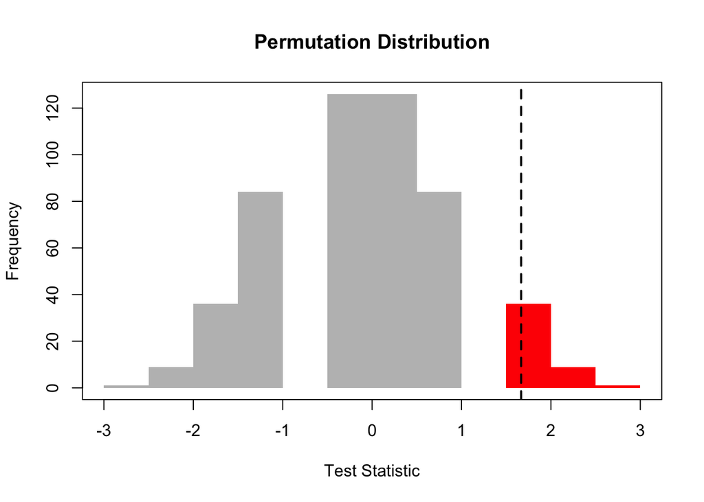

```r
plot(mod)
```

### 3.3.4 Confidence Interval

To get the confidence bound:

```r
z <- x - y                        # difference score
n <- length(z)                    # number of observations
zs <- sort(z)                     # order statistics
bu <- 0:n                         # possible B values
pbinom(bu, n, 1/2)                # achievable alpha levels (from binomial CDF)
```

```
##  [1] 0.001953125 0.019531250 0.089843750 0.253906250 0.500000000 0.746093750
##  [7] 0.910156250 0.980468750 0.998046875 1.000000000
```

```r
pbinom(bu[2], n, 1/2)             # b = bu[2] = 1 gives 0.019531250
```

```
## [1] 0.01953125
```

```r
pbinom(bu[3], n, 1/2)             # b = bu[3] = 2 gives 0.089843750
```

```
## [1] 0.08984375
```

```r
irat.top <- 0.05 - pbinom(bu[2], n, 1/2)      # dist from lower to desired
irat.bot <- diff(pbinom(bu[2:3], n, 1/2))     # dist from lower to upper
irat <- irat.top / irat.bot                   # interpolation ratio
zs[2] + (zs[3] - zs[2]) * irat                # interpolate between order stats
```

```
## [1] -0.041
```

```r
zs                                            # print order statistics
```

```
## [1] -0.147 -0.080  0.010  0.430  0.490  0.590  0.620  0.952  1.022
```